# **Topic 11 - ggplot2: Grammar of Graphics**

Esam Mahdi

2026-05-04

# Introduction to R Graphics

**Why use ggplot2?**

- **Consistent grammar** - Unlike base **R** plots, **ggplot2** uses a unified “grammar of graphics” approach
- **Layered construction** - Build plots step by step, making complex visualizations manageable
- **Beautiful defaults** - Produces publication-ready graphics with minimal code
- **Easy customization** - Modify almost every aspect of your plot

## The Grammar of Graphics

`ggplot2` is built on a simple idea: **every plot has three components**:

- **Data** - The dataset you want to visualize
- **Mapping (aes)** - How variables map to visual properties (x position, y position, color, size, etc.)
- **Geoms** - The geometric objects that represent your data (`points`, `bars`, `lines`, etc.)

```
ggplot(data = DATAFRAME,
       mapping = aes(x = VAR1, y = VAR2)) +
  geom_TYPE()
```

# The `mpg` Dataset

The `mpg` dataset contains fuel economy data from 1999 to 2008 for 234 popular car models:

**Variable Descriptions**

| Variable | Type | Description |
| --- | --- | --- |
| `manufacturer` | Categorical | Car manufacturer (15 levels) |
| `model` | Categorical | Car model |
| `displ` | Quantitative | Engine displacement in liters |
| `year` | Categorical | Year of manufacture (1999 or 2008) |
| `cyl` | Categorical/Ordinal | Number of cylinders (4, 5, 6, 8) |
| `trans` | Categorical | Transmission type |
| `drv` | Categorical | Drive type: f = front, r = rear, 4 = 4wd |
| `cty` | Quantitative | City miles per gallon |
| `hwy` | Quantitative | Highway miles per gallon |
| `fl` | Categorical | Fuel type |
| `class` | Categorical | Vehicle class (7 levels) |

```
# Load required packages
library(tidyverse) # Recall tidyverse includes ggplot2 and dplyr

# Load the mpg dataset (comes with ggplot2)
data(mpg)

# Explore the dataset
glimpse(mpg)
```

**Step 1: The `ggplot()` Function**

The `ggplot()` function initializes the plot. Notice it creates an empty canvas:

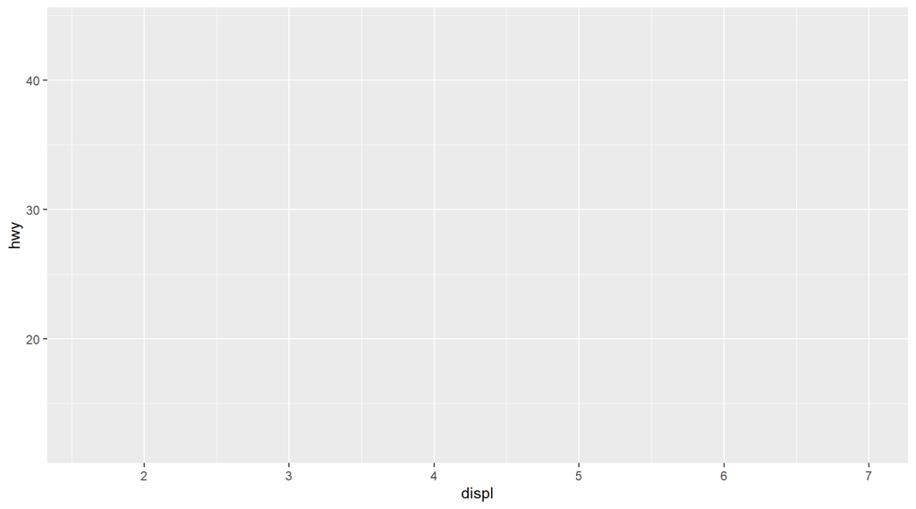

```r
# Empty canvas - nothing appears yet!
ggplot(data = mpg, mapping = aes(x = displ, y = hwy))
```

**Step 2: Add Geoms (Geometric Objects)**

Geoms are the actual visual elements. Add them with `+:`

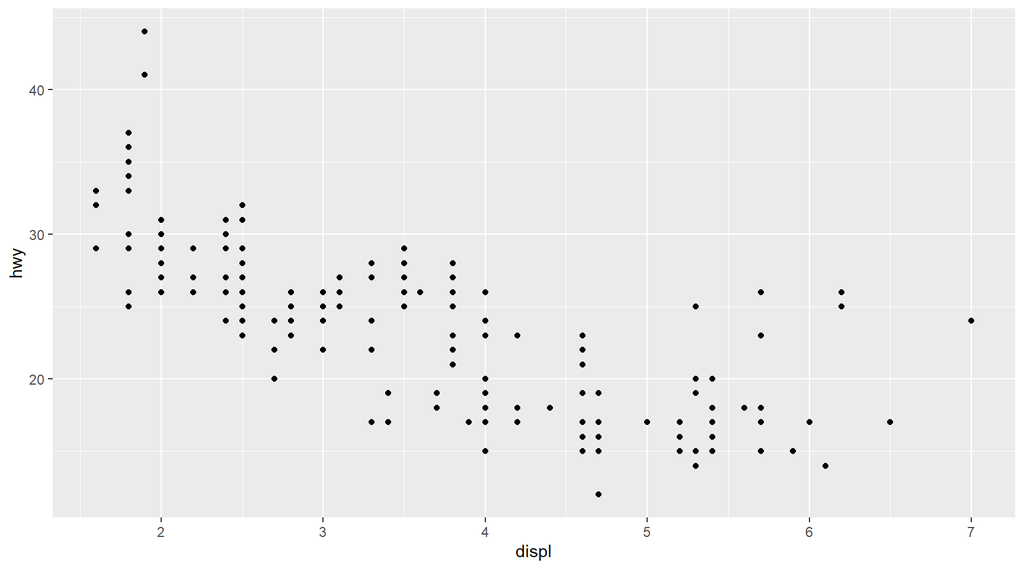

```r
# Add points to create a scatterplot
ggplot(data = mpg, mapping = aes(x = displ, y = hwy)) +
  geom_point()
```

**Interpretation:** There is a negative relationship between engine displacement and highway MPG. Cars with larger engines tend to have lower fuel efficiency.

```r
# Alternatively, you can get the same plot using any of the following methods:
# ggplot(data = mpg) + geom_point(mapping = aes(x = displ, y = hwy))

# or
# ggplot() + geom_point(data = mpg, mapping = aes(x = displ, y = hwy))

# or
# mpg %>% ggplot(mapping = aes(x = displ, y = hwy)) + geom_point()

# or
# mpg %>% ggplot() + geom_point(mapping = aes(x = displ, y = hwy))
```

# Geom Functions

| Function | Layers | Options |
| --- | --- | --- |
| `geom_point()` | Scatterplot | `color (or colour)`, `alpha`, `shape`, `size` |
| `geom_line()` | Line graph | `color (or colour)`, `alpha`, `linetype`, `size` |
| `geom_jitter()` | Jittered points | `color (or colour)`, `size`, `alpha`, `shape` |
| `geom_bar()` | Bar chart | `color (or colour)`, `fill`, `alpha` |
| `geom_boxplot()` | Box plot | `color (or colour)`, `fill`, `alpha`, `notch`, `width` |
| `geom_histogram()` | Histogram | `color (or colour)`, `fill`, `alpha`, `linetype`, `binwidth` |
| `geom_smooth()` | Fitted line | `method`, `formula`, `color (or colour)`, `fill`, `linetype`, `size` |
| `geom_density()` | Density plot | `color (or colour)`, `fill`, `alpha`, `linetype` |
| `geom_hline()` | Horizontal lines | `color (or colour)`, `alpha`, `linetype`, `size` |
| `geom_vline()` | Vertical lines | `color (or colour)`, `alpha`, `linetype`, `size` |
| `geom_rug()` | Rug plot | `color (or colour)`, `side` |
| `geom_violin()` | Violin plot | `color (or colour)`, `fill`, `alpha`, `linetype` |
| `geom_text()` | Text annotations | See the help for this function |

**Step 3: Customize Appearance**

Modify colors, sizes, transparency, and theme:

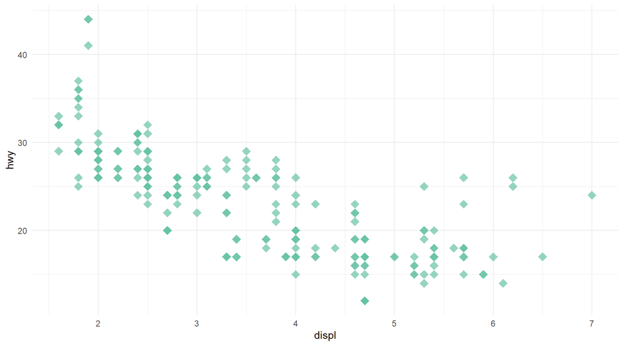

```r
# Customized scatterplot
ggplot(data = mpg, mapping = aes(x = displ, y = hwy)) +
  geom_point(color = "#66C2A5", size = 4, alpha = 0.7, shape = 18) +
  theme_minimal() # Change the default gray theme to minimal theme
```

## Key Parameters For `geom_point():`

| Parameter | Description | Example |
| --- | --- | --- |
| `color (or colour)` | Changes the visual color of the object (points, lines, etc.) | `color = "steelblue"` (Default is black) |
| `size` | Controls the thickness of lines or the diameter of points | `size = 4` (Default is 1) |
| `alpha` | Sets the transparency level between 0 and 1 (0 is invisible, 1 is solid) | `alpha = 0.7` (Default is 1) |
| `shape` | Changes the style of the point. It takes integer values from 0 to 25 (e.g., circles, squares, triangles) | `shape = 18` (Default: `16` = filled circle) |

**Step 4: Add a Trend Line**

Use `geom_smooth()` to add lines of best fit:

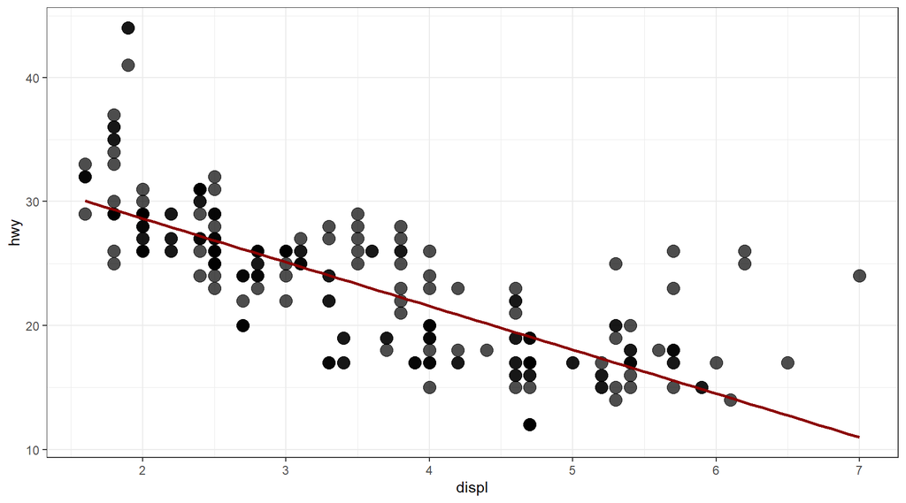

```r
# Scatterplot with regression line (not I use %>%)
# se = FALSE to skip plotting the confidence interval of standard error and only draw the smoothed line
mpg %>%
  ggplot(mapping = aes(x = displ, y = hwy)) +
  geom_point(size = 4, alpha = 0.7) +
  geom_smooth(method = "lm", color = "darkred", se = FALSE) +
  theme_bw() # Black white theme
```

**Step 5: Map Variables to Aesthetics**

Instead of fixed colors, map variables to visual properties. Let’s map `class` (vehicle class type) to color, and plot the best-fit line (linear regression) to each class data points:

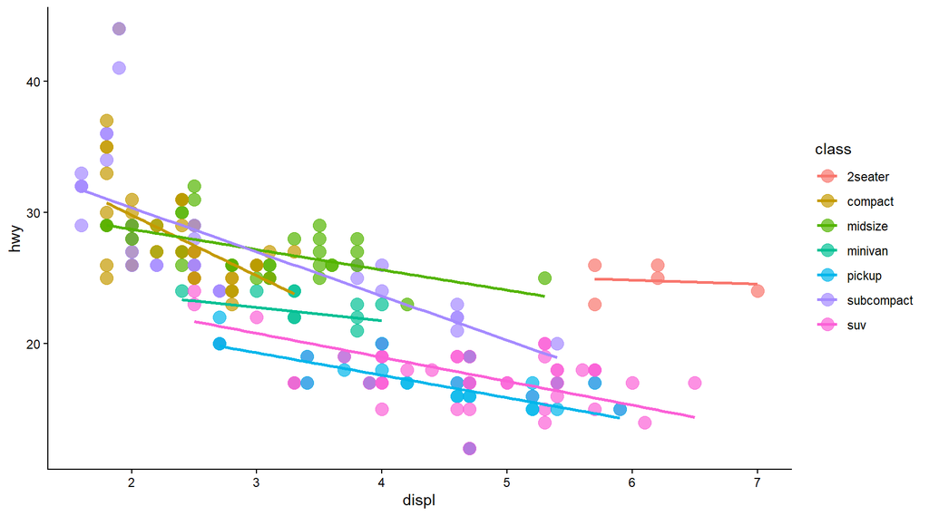

```r
# Color points by vehicle class type
ggplot(mpg, aes(displ, hwy, color = class)) +
  geom_point(size = 4, alpha = 0.7) +
  geom_smooth(method = "lm", se = FALSE) +
  theme_classic() # Classical theme
```

Now let’s map `cyl` (cylinders) to color and shape, and plot the best of fit line to each number of cylinder data points:

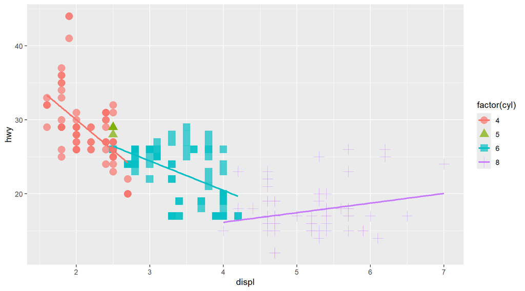

```r
# Color points by number of cylinders and change the shapes
mpg %>%
ggplot(aes(x = displ, y = hwy, color = factor(cyl), shape = factor(cyl))) +
  geom_point(size = 4, alpha = 0.7) +
  geom_smooth(method = "lm", se = FALSE)
```

**Step 6: Add Labels**

Make your plot informative with `labs()`:

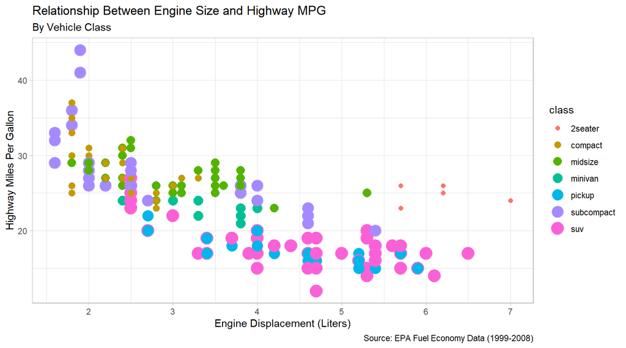

```r
# Add informative labels and note that I map the class of the cars to color and size
ggplot(data = mpg, mapping = aes(x = displ, y = hwy, colour = class, size = class)) +
  geom_point() +
  labs(
    title = "Relationship Between Engine Size and Highway MPG",
    subtitle = "By Vehicle Class",
    x = "Engine Displacement (Liters)",
    y = "Highway Miles Per Gallon",
    caption = "Source: EPA Fuel Economy Data (1999-2008)") +
  theme_light() # Light theme
```

**Interpretation:** As engine displacement increases, highway (miles per gallon) MPG generally decreases (negative correlation). Different vehicle classes cluster in different regions:

- **SUVs/pickups** → Large engines, low MPG
- **Compact/subcompact** → Small engines, high MPG
- **Midsize** → Middle ranges

**Step 7: Modify Scales**

Control axes with `scale_*()` functions:

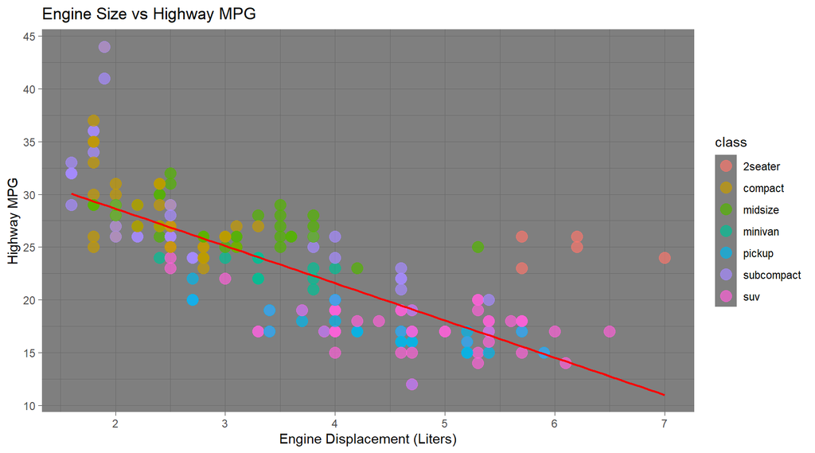

```r
# Customize scales
p1 <- ggplot(data = mpg, mapping = aes(displ, hwy, color = class)) +
  geom_point(size = 4, alpha = 0.7) +
  geom_smooth(method = "lm", se = FALSE, color = "red", size = 0.8) +
  labs(
    title = "Engine Size vs Highway MPG",
    x = "Engine Displacement (Liters)",
    y = "Highway MPG"
  ) +
  scale_x_continuous(breaks = seq(1, 7, 1)) +
  scale_y_continuous(breaks = seq(10, 45, 5))

p1 + theme_dark() # Dark theme
```

# Faceting: Multiple Plots by Group

One of ggplot2’s most powerful features is **faceting** - creating multiple panels based on a categorical variable.

## Facet Wrap (Single Variable)

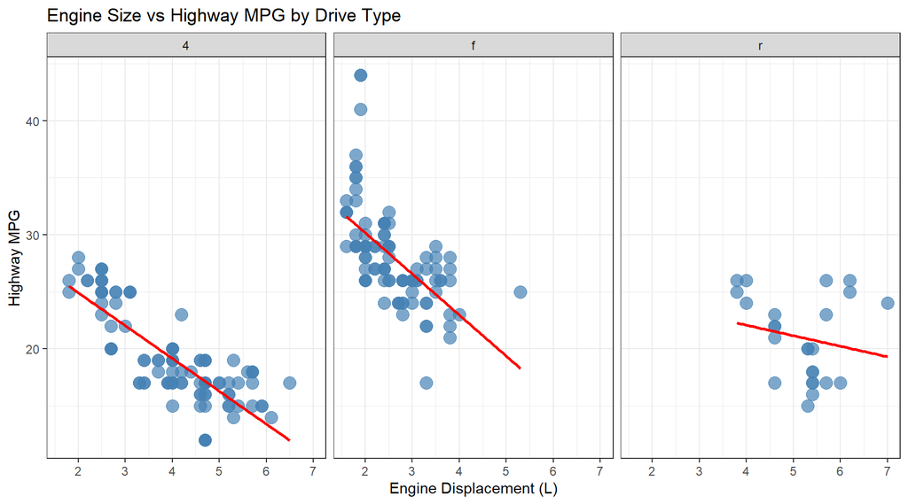

```r
# Facet by drive type
ggplot(mpg, aes(x = displ, y = hwy)) +
  geom_point(color = "steelblue", size = 4, alpha = 0.7) +
  geom_smooth(method = "lm", se = FALSE, color = "red") +
  facet_wrap(~drv, ncol = 3) +
  labs(
    title = "Engine Size vs Highway MPG by Drive Type",
    x = "Engine Displacement (L)",
    y = "Highway MPG") +
  theme_bw()
```

**Interpretation:** The negative relationship between engine size and MPG is strongest for front-wheel drive cars.

**Parameters for faceting:**

| Function | Description | Example |
| --- | --- | --- |
| `facet_wrap()` | Creates a 1D ribbon of panels for each level of a variable | `facet_wrap(~variable)` |
| `facet_grid()` | Creates a 2D grid of panels defined by two variables | `facet_grid(row ~ col)` |
| `ncol` | Sets the specific number of columns in the layout | `ncol = 3` |
| `nrow` | Sets the specific number of rows in the layout | `nrow = 2` |
| `scales` | Determines if axis scales are shared or independent across panels | `scales = "free"` |

## Facet Grid (Two Variables)

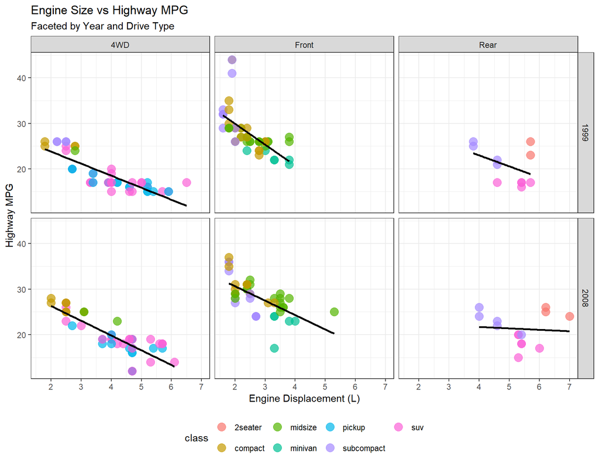

```r
# Facet by year and drive type
ggplot(mpg, aes(x = displ, y = hwy)) +
  geom_point(size = 4, alpha = 0.7, aes(color = class)) +
  geom_smooth(method = "lm", se = FALSE, color = "black") +
  facet_grid(year ~ drv,
             labeller = labeller(drv = c("4" = "4WD", "f" = "Front", "r" = "Rear"))) +
  labs(
    title = "Engine Size vs Highway MPG",
    subtitle = "Faceted by Year and Drive Type",
    x = "Engine Displacement (L)",
    y = "Highway MPG") +
  theme_bw() +
  theme(legend.position = "bottom")
```

**Scales argument in `facet_wrap()` and `facet_grid()`**

The `scales` argument in `facet_wrap()` and `facet_grid()` controls whether axis scales are shared (“fixed”, default) or allowed to vary (`"free"`, `"free_x"`, `"free_y"`) across panels, enabling easier comparison within or between subsets. This is especially useful for comparing plots with widely different data ranges

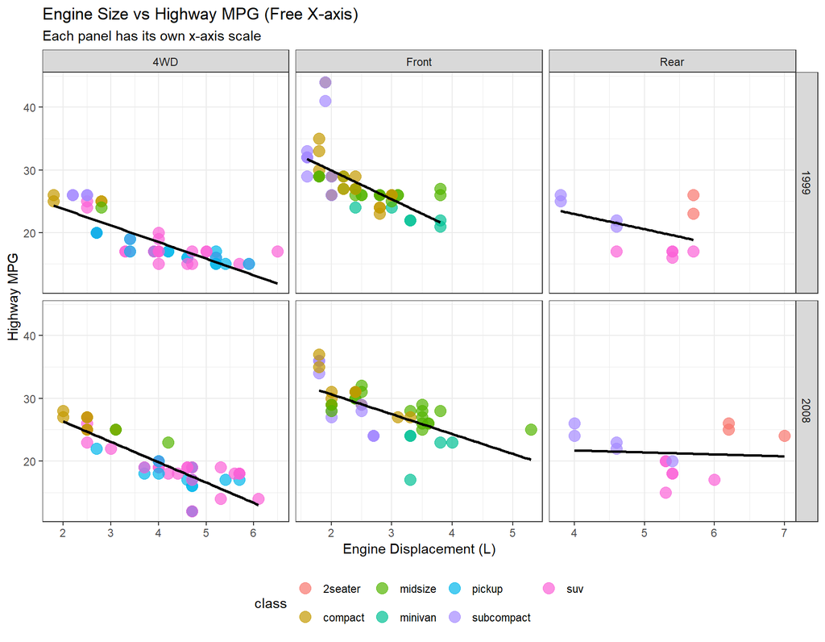

```r
# Free x - each panel has its own x-axis scale
ggplot(mpg, aes(x = displ, y = hwy)) +
  geom_point(size = 4, alpha = 0.7, aes(color = class)) +
  geom_smooth(method = "lm", se = FALSE, color = "black") +
  facet_grid(year ~ drv,
             scales = "free_x",  # Free x-axis only
             labeller = labeller(drv = c("4" = "4WD", "f" = "Front", "r" = "Rear"))) +
  labs(
    title = "Engine Size vs Highway MPG (Free X-axis)",
    subtitle = "Each panel has its own x-axis scale",
    x = "Engine Displacement (L)",
    y = "Highway MPG") +
  theme_bw() +
  theme(legend.position = "bottom")
```

**Scales options in facetting**

| `scales` argument | Description | When to Use |
| --- | --- | --- |
| `"fixed"` (default) | Every panel uses the exact same x and y scale | When comparing panels directly and data ranges are similar |
| `"free_x"` | Each panel has its own x-axis scale; y-axis remains the same | When panels have different x-axis ranges but comparable y-values |
| `"free_y"` | Each panel has its own y-axis scale; x-axis remains the same | When panels have different y-axis ranges but comparable x-values |
| `"free"` | Both x and y scales are independent for each panel | When panels have very different ranges for both axes |

# Bar Charts with `geom_bar()`

The `geom_bar()` is designed to visualize the distribution of a single (or multiple) **categorical variable** by calculating and displaying the **total count** for each category as bar heights.

**Basic bar chart**

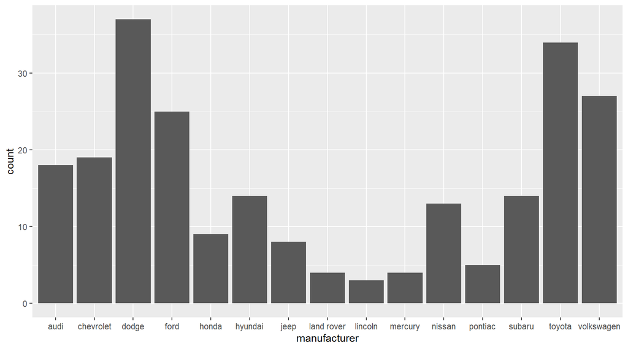

```r
# Bar chart for manufacturer (categorical variable) distribution
ggplot(mpg, aes(x = manufacturer)) +
  geom_bar()
```

**Interpretation:** `Dodge`, `Toyota`, and `Volkswagen` have the most models in the dataset.

## Customized Bar Chart

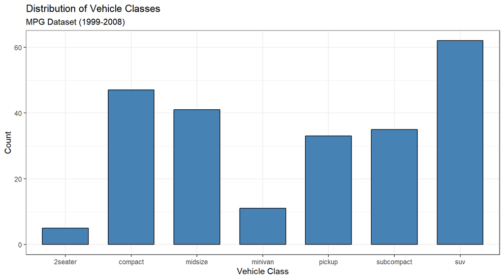

```r
# Enhanced bar chart for vehicle class variable
ggplot(mpg, aes(x = class)) +
  geom_bar(fill = "steelblue", color = "black", width = 0.7) +
  labs(
    title = "Distribution of Vehicle Classes",
    subtitle = "MPG Dataset (1999-2008)",
    x = "Vehicle Class",
    y = "Count") +
  theme_bw()
```

**Interpretation:** `SUV` and `compact` cars are most common, while `2seaters` are rarest.

## Key Parameters For `geom_bar()`:

[output not shown]

## Bar Chart with Percentages

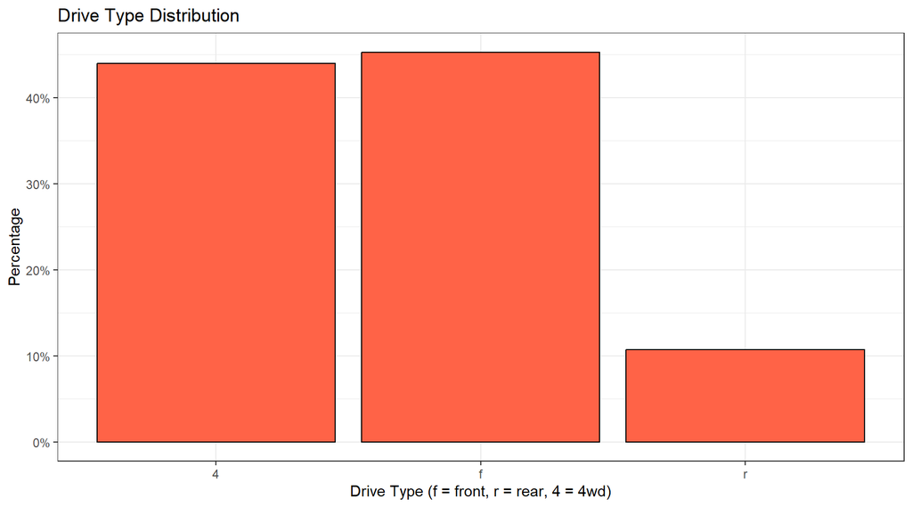

```r
# Percentages on y-axis for drive type variable
# Load the scales package first
library(scales)

# Now the code will work
ggplot(mpg, aes(x = drv, y = after_stat(count / sum(count)))) +
    geom_bar(fill = "tomato", color = "black") +
    scale_y_continuous(labels = percent) +
    labs(
        title = "Drive Type Distribution",
        x = "Drive Type (f = front, r = rear, 4 = 4wd)",
        y = "Percentage"
    ) +
    theme_bw()
```

**Interpretation:** `Front-wheel` drive is the most common, followed by `4WD`.

## Sorting Bars by Frequency

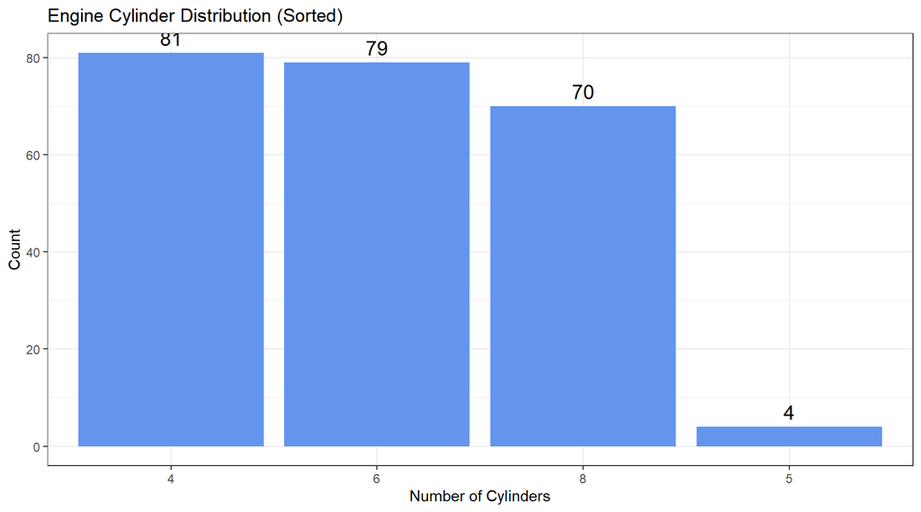

```r
# Sort bars in descending order for cylinders variable
mpg %>%
  count(cyl) %>%
  mutate(cyl = reorder(factor(cyl), -n)) %>%
  ggplot(aes(x = cyl, y = n)) +
  geom_bar(stat = "identity", fill = "cornflowerblue") +
  geom_text(aes(label = n), vjust = -0.5, size = 5) +
  labs(x = "Number of Cylinders", y = "Count", title = "Engine Cylinder Distribution (Sorted)") +
  theme_bw()
```

**Interpretation:** `4-cylinder` and `6-cylinder` engines are most common. `5-cylinder` engines are rare.

## Horizontal Bar Chart

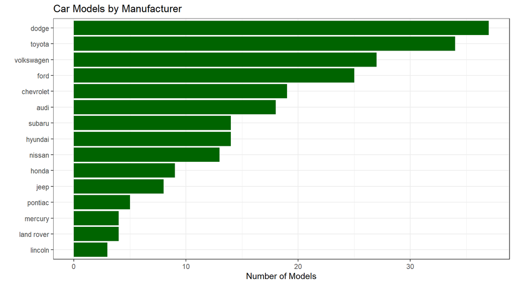

```r
# Horizontal bar chart for manufacturers variable
manufacturer_counts <- mpg %>%
  count(manufacturer) %>%
  arrange(n)

ggplot(manufacturer_counts, aes(x = reorder(manufacturer, n), y = n)) +
  geom_bar(stat = "identity", fill = "darkgreen") +
  coord_flip() +
  labs(x = "", y = "Number of Models", title = "Car Models by Manufacturer") +
  theme_bw()
```

# Histograms with `geom_histogram()`

The `geom_histogram()` function is designed to visualize the distribution of a single (or more) **continuous quantitative variable** by splitting the data into equal-width bins and plotting the **counts of observations** within each bin using **bars**.

**Basic histogram**

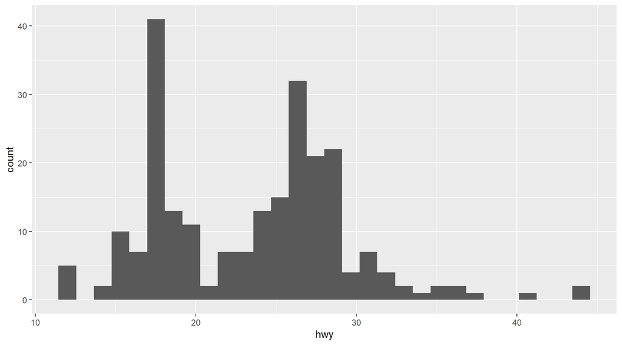

```r
# Basic histogram
ggplot(mpg, aes(x = hwy)) +
  geom_histogram()
```

**Interpretation:** Most cars get between 20-30 MPG on the highway.

**Customized histogram - city MPG**

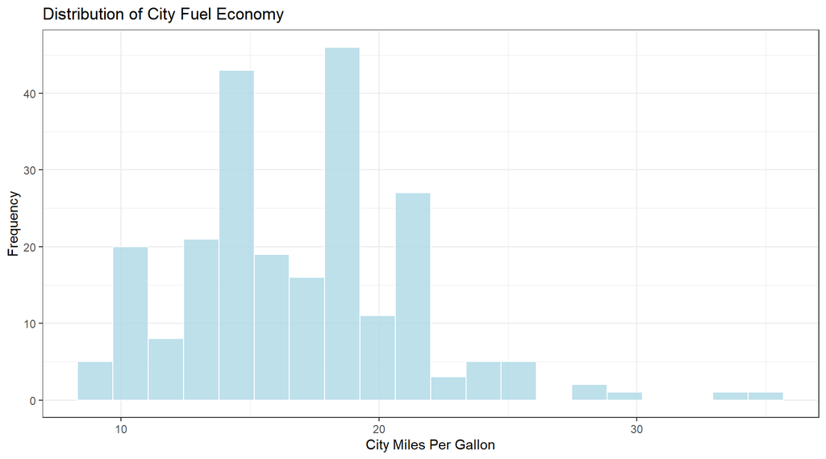

```r
# Customized histogram for city MPG
ggplot(mpg, aes(x = cty)) +
  geom_histogram(
    fill = "lightblue",
    color = "white",
    bins = 20,
    alpha = 0.8
  ) +
  labs(
    title = "Distribution of City Fuel Economy",
    x = "City Miles Per Gallon",
    y = "Frequency") +
  theme_bw()
```

## Key Parameters For `geom_histogram()`:

| Parameter | Description | Example |
| --- | --- | --- |
| `bins` | Sets the total number of bars (bins) in the plot | `bins = 20` |
| `binwidth` | Sets the width of each bar in the units of the x-axis variable | `binwidth = 5` |
| `fill` | Changes the interior color of the bars | `fill = "lightblue"` |
| `color` | Changes the color of the border/outline between bars | `color = "white"` |
| `alpha` | Sets the transparency level (0 to 1) | `alpha = 0.8` |

## Controlling Bin Width

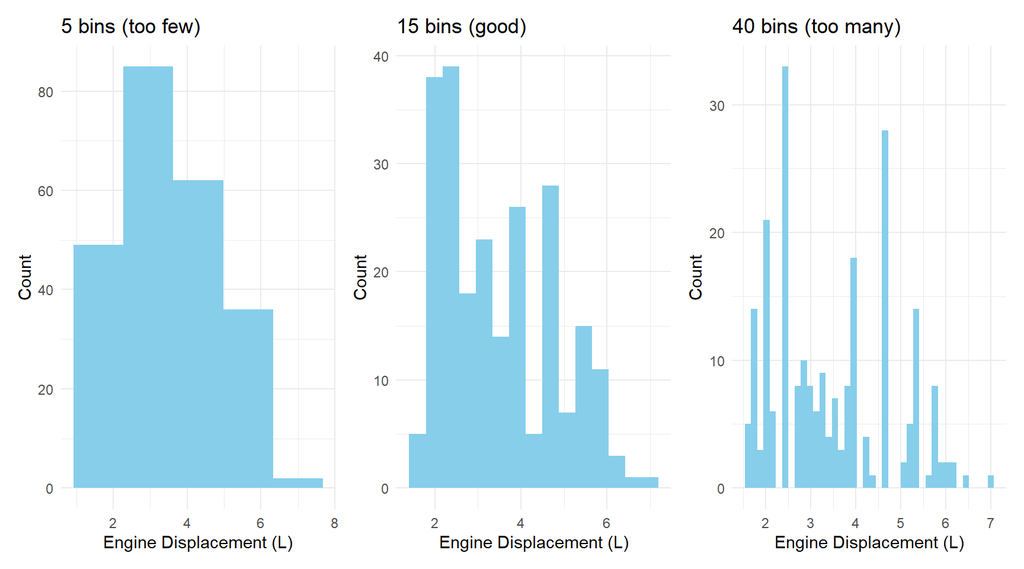

```r
# Compare different bin widths (for engine displacement variable)
p1 <- ggplot(mpg, aes(x = displ)) +
  geom_histogram(fill = "skyblue", bins = 5) +
  labs(title = "5 bins (too few)", x = "Engine Displacement (L)", y = "Count") +
  theme_minimal()

p2 <- ggplot(mpg, aes(x = displ)) +
  geom_histogram(fill = "skyblue", bins = 15) +
  labs(title = "15 bins (good)", x = "Engine Displacement (L)", y = "Count") +
  theme_minimal()

p3 <- ggplot(mpg, aes(x = displ)) +
  geom_histogram(fill = "skyblue", bins = 40) +
  labs(title = "40 bins (too many)", x = "Engine Displacement (L)", y = "Count") +
  theme_minimal()

library(patchwork) # To combine separate ggplot2 plots into a single aligned multi-panel figure
p1 + p2 + p3
```

## Histogram with Density Curve

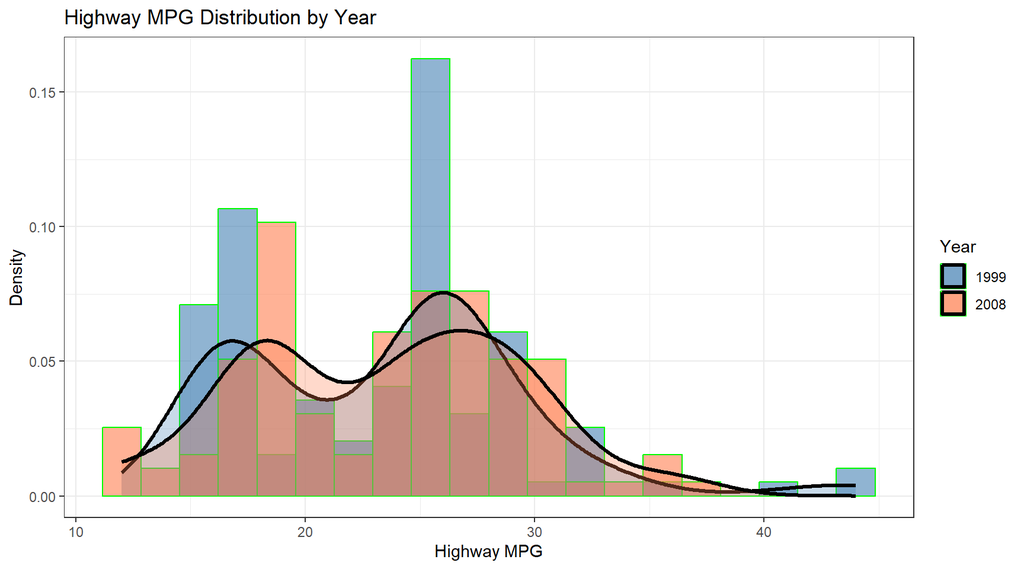

```r
# Histogram with density overlay (for highway MPG by year variable)
ggplot(mpg, aes(x = hwy, y = after_stat(density), fill = factor(year))) +
  geom_histogram(color = "green", bins = 20, alpha = 0.6, position = "identity") +
  geom_density(size = 1.2, alpha = 0.3) +
  scale_fill_manual(values = c("steelblue", "coral"), name = "Year") +
  labs(
    title = "Highway MPG Distribution by Year",
    x = "Highway MPG",
    y = "Density") +
  theme_bw()
```

## Adding Summary Statistics

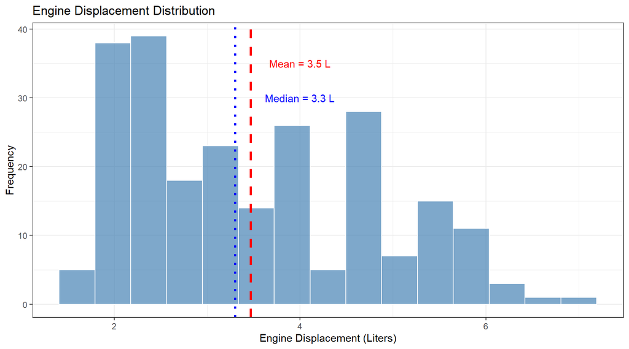

```r
# Calculate statistics (for engine displacement variable)
mean_displ <- mean(mpg$displ)
median_displ <- median(mpg$displ)

# Plot the histogram with mean and median lines (for engine displacement variable)
ggplot(mpg, aes(x = displ)) +
  geom_histogram(fill = "steelblue", color = "white", bins = 15, alpha = 0.7) +
  geom_vline(xintercept = mean_displ, color = "red", size = 1.2, linetype = "dashed") +
  geom_vline(xintercept = median_displ, color = "blue", size = 1.2, linetype = "dotted") +
  annotate("text", x = 4, y = 35,
           label = paste("Mean =", round(mean_displ, 1), "L"), color = "red") +
  annotate("text", x = 4, y = 30,
           label = paste("Median =", round(median_displ, 1), "L"), color = "blue") +
  labs(
    title = "Engine Displacement Distribution",
    x = "Engine Displacement (Liters)",
    y = "Frequency") +
  theme_bw()
```

## Histogram with Faceting

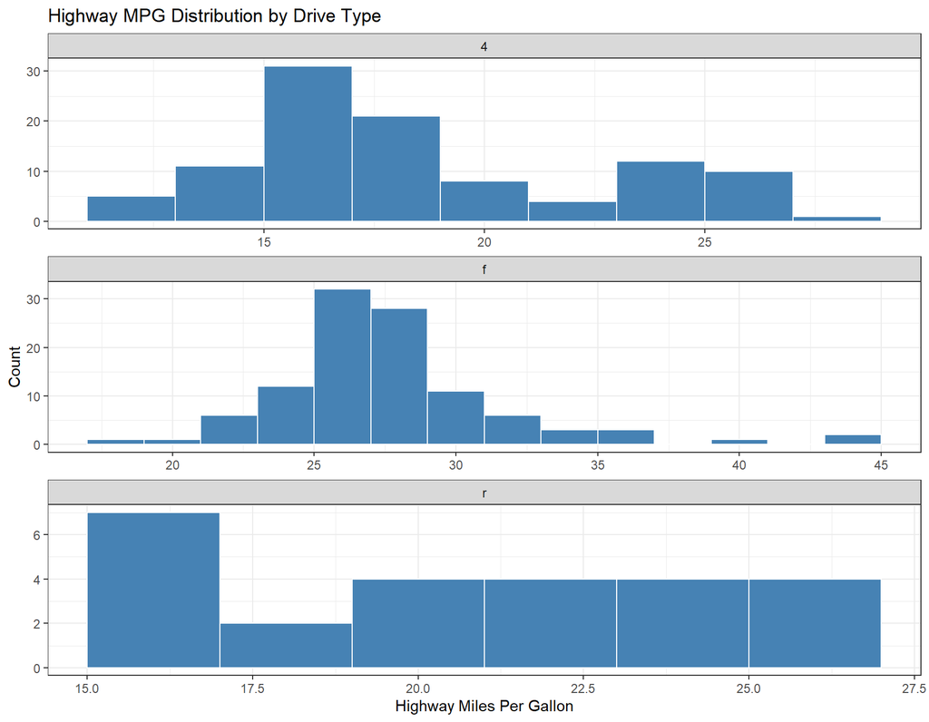

```r
ggplot(mpg, aes(x = hwy)) +
  geom_histogram(binwidth = 2, fill = "steelblue", color = "white") +
  facet_wrap(~ drv, ncol = 1, scales = "free") +
  labs(
    title = "Highway MPG Distribution by Drive Type",
    x = "Highway Miles Per Gallon",
    y = "Count"
  ) +
  theme_bw()
```

# Boxplots with `geom_boxplot()`

A **boxplot** (or box-and-whisker plot) is a standardized way of displaying the distribution of a variable based on a **five-number summary:**

| Component | Description | Calculation / Definition |
| --- | --- | --- |
| **Minimum** | Smallest value | $Q1 - 1.5 \times IQR$ |
| **Q1** (First Quartile) | 25th percentile | 25% of data falls below this value |
| **Median** (Q2) | 50th percentile | The middle value of the dataset |
| **Q3** (Third Quartile) | 75th percentile | 75% of data falls below this value |
| **Maximum** | Largest value | $Q3 + 1.5 \times IQR$ |
| **IQR** | Interquartile Range | $Q3 - Q1$ |

**The boxplot will display:**

- **Median** (middle line inside the box) - the 50th percentile
- **Box** spanning from Q1 (25th percentile) to Q3 (75th percentile) - the interquartile range (IQR)
- **Whiskers** extending to:
  - Q1 - 1.5×IQR (lower bound)
  - Q3 + 1.5×IQR (upper bound)
- **Points** beyond the whiskers (potential **outliers**)

**Basic Boxplot**

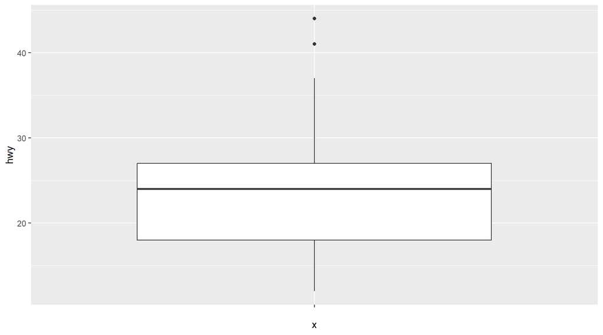

```r
# Basic single boxplot - highway MPG distribution
ggplot(mpg, aes(x = "", y = hwy)) + # Note: "ggplot(mpg, aes(hwy))" produces a boxplot with the coordinates flipped horizontally
  geom_boxplot()
```

We can conclude that the distribution (of **all cars**) is **left-skewed** (because the median is closer to the right side of the box) with two high-end potential **outliers**.

## Grouped Boxplots (Categorical X-axis)

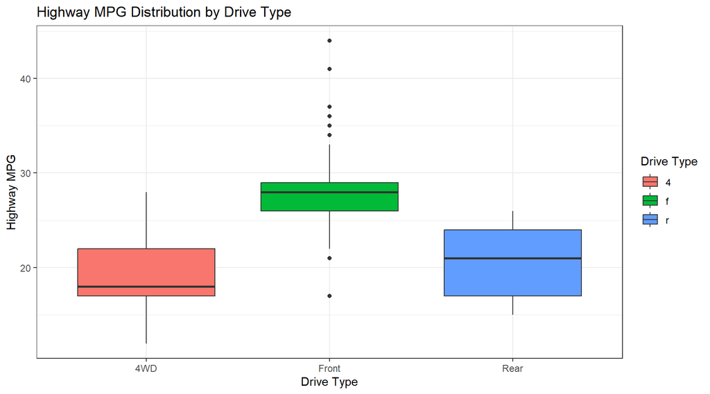

```r
# Boxplot by drive type (categorical variable)
ggplot(mpg, aes(x = drv, y = hwy, fill = drv)) +
  geom_boxplot() +
  scale_x_discrete(labels = c("4" = "4WD", "f" = "Front", "r" = "Rear")) +
  labs(
    title = "Highway MPG Distribution by Drive Type",
    x = "Drive Type",
    y = "Highway MPG",
    fill = "Drive Type") +
  theme_bw()
```

## Customizing Boxplots

### Changing Colors and Appearance

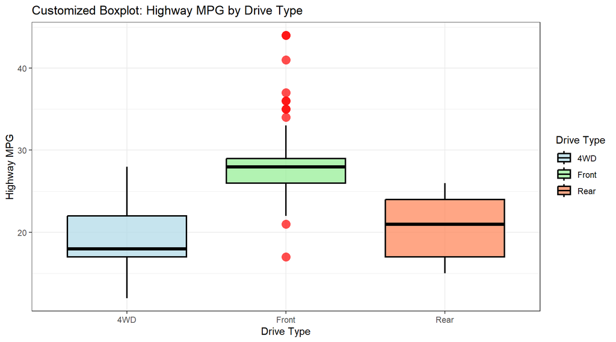

```r
# Customized boxplot with specific colors
ggplot(mpg, aes(x = drv, y = hwy, fill = drv)) +
  geom_boxplot(
    alpha = 0.7,
    color = "black",
    size = 0.8,
    outlier.color = "red",
    outlier.size = 4,
    outlier.shape = 16
  ) +
  scale_fill_manual(values = c("lightblue", "lightgreen", "coral"),
                    labels = c("4WD", "Front", "Rear")) +
  scale_x_discrete(labels = c("4" = "4WD", "f" = "Front", "r" = "Rear")) +
  labs(
    title = "Customized Boxplot: Highway MPG by Drive Type",
    x = "Drive Type",
    y = "Highway MPG",
    fill = "Drive Type") +
  theme_bw()
```

### Horizontal Boxplots

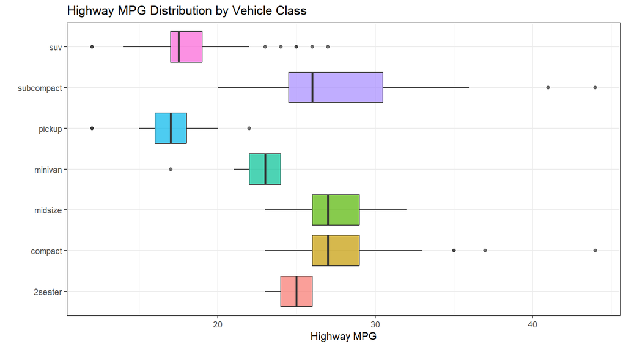

```r
# Horizontal orientation (useful when category labels are long)
ggplot(mpg, aes(x = class, y = hwy, fill = class)) +
  geom_boxplot(alpha = 0.7) +
  coord_flip() +  # Flip coordinates to make horizontal
  labs(
    title = "Highway MPG Distribution by Vehicle Class",
    x = "",
    y = "Highway MPG",
    fill = "Vehicle Class") +
  theme_bw() +
  theme(legend.position = "none")
```

### Boxplot with Faceting

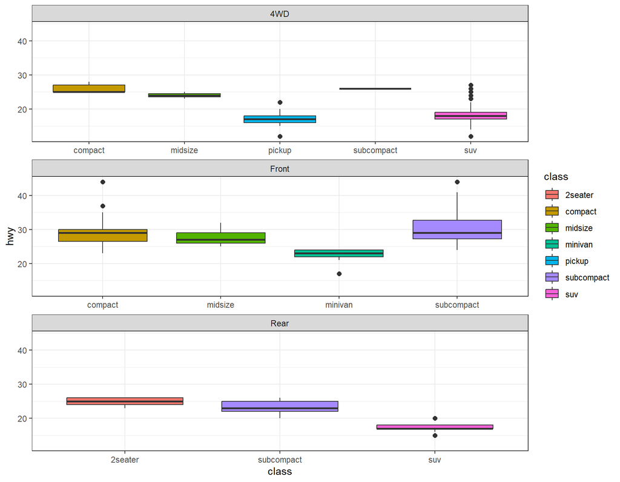

```r
# Boxplot of highway MPG by vehicle class, faceted by drive type
mpg %>%
  ggplot(aes(x = class, y = hwy, fill = class)) +
  geom_boxplot(outlier.size = 2) +
  facet_wrap(~drv, nrow = 3, scales = "free_x",
             labeller = labeller(drv = c("4" = "4WD", "f" = "Front", "r" = "Rear"))) +
  theme_bw()
```

### Comprehensive Comparison: Boxplot vs Violin Plot

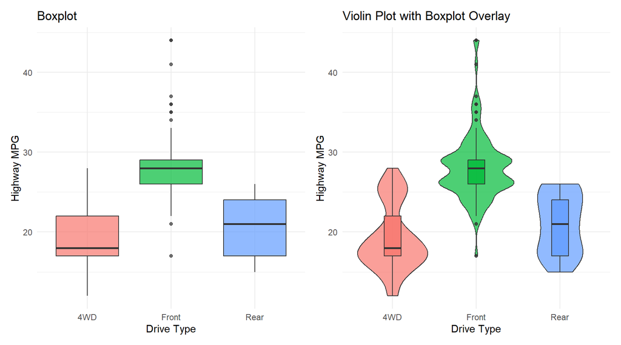

```r
# Compare boxplot with violin plot
library(patchwork)

# Boxplot
p_box <- ggplot(mpg, aes(x = drv, y = hwy, fill = drv)) +
  geom_boxplot(alpha = 0.7) +
  scale_x_discrete(labels = c("4" = "4WD", "f" = "Front", "r" = "Rear")) +
  labs(title = "Boxplot", x = "Drive Type", y = "Highway MPG") +
  theme_minimal() +
  theme(legend.position = "none")

# Violin plot (shows full distribution shape)
p_violin <- ggplot(mpg, aes(x = drv, y = hwy, fill = drv)) +
  geom_violin(alpha = 0.7) +
  geom_boxplot(width = 0.2, alpha = 0.8) +
  scale_x_discrete(labels = c("4" = "4WD", "f" = "Front", "r" = "Rear")) +
  labs(title = "Violin Plot with Boxplot Overlay", x = "Drive Type", y = "Highway MPG") +
  theme_minimal() +
  theme(legend.position = "none")

# Arrange side by side
p_box + p_violin
```

**Note:** **Boxplots** provide a concise **summary of distribution** through quartiles and outliers, making them ideal for comparing multiple groups. **Violin plots** extend this by showing the full **probability density**, revealing multimodal distributions that boxplots might miss. Use **boxplots** for precise quantile comparisons; use **violin plots** when understanding the complete shape of the distribution matters.